# R Notebook

# Discriminant analysis

## Discriminant analysis

- ANOVA and MANOVA: predict a (counted/measured) response from group membership.
- Discriminant analysis: predict group membership based on counted/measured variables.
- Covers same ground as logistic regression (and its variations), but emphasis on classifying observed data into correct groups.
- Does so by searching for linear combination of original variables that best separates data into groups (canonical variables).
- Assumption here that groups are known (for data we have). If trying to “best separate” data into unknown groups, see *cluster analysis*.
- Examples: revisit seed yield and weight data, peanut data, professions/activities data; remote-sensing data.

## Packages

```r
library(MASS)
library(tidyverse)
library(ggrepel)
```

`ggrepel` allows labelling points on a plot so they don’t overwrite each other.

## About `select`

- Both `dplyr` (in `tidyverse`) and `MASS` have a function called `select`, and *they do different things*.
- How do you know which `select` is going to get called?
- With `library`, the one loaded *last* is visible, and others are not.
- Thus we can access the `select` in `dplyr` but not the one in `MASS`. If we wanted that one, we’d have to say `MASS::select`.
- This is why I loaded `MASS` before `tidyverse`. If I had done it the other way around, the `tidyverse` `select`, which I want to use, would have been the invisible one.

## Example 1: seed yields and weights

```r
my_url="http://www.utsc.utoronto.ca/~butler/d29/manova1.txt"
hilo=read_delim(my_url," ")
g=ggplot(hilo,aes(x=yield,y=weight,
  colour=fertilizer))+geom_point(size=4)
```

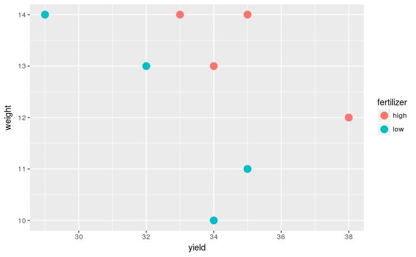

```r
g
```

Recall data from MANOVA: needed a multivariate analysis to find difference in seed yield and weight based on whether they were high or low fertilizer.

## Basic discriminant analysis

```r
hilo.1=lda(fertilizer~yield+weight,data=hilo)
```

- Uses `lda` from package MASS.
- “Predicting” group membership from measured variables.

## Output

```r
hilo.1
```

```
Call:
lda(fertilizer ~ yield + weight, data = hilo)

Prior probabilities of groups:
high  low
 0.5  0.5

Group means:
     yield weight
high  35.0  13.25
low   32.5  12.00

Coefficients of linear discriminants:
              LD1
yield  -0.7666761
weight -1.2513563
```

## How many linear discriminants?

- Number of variables
- Number of groups *minus 1*
- Smaller of these
- Seed yield and weight: 2 variables, 2 groups, $\min(2,2-1)=1$.

## Getting LD scores

Feed output from LDA into `predict`:

```r
hilo.pred=predict(hilo.1)
```

Component $x$ contains LD score(s), here in descending order:

```r
d = cbind(hilo,hilo.pred$x) %>% arrange(desc(LD1))
d
```

| fertilizer | yield | weight | LD1 |
| --- | --- | --- | --- |
| low | 34 | 10 | 3.0931414 |
| low | 29 | 14 | 1.9210963 |
| low | 35 | 11 | 1.0751090 |
| low | 32 | 13 | 0.8724245 |
| high | 34 | 13 | -0.6609276 |
| high | 33 | 14 | -1.1456079 |
| high | 38 | 12 | -2.4762756 |
| high | 35 | 14 | -2.6789600 |

High fertilizer have yield and weight high, negative LD1 scores.

## Plotting LD1 scores

With one LD score, plot against (true) groups, eg. boxplot:

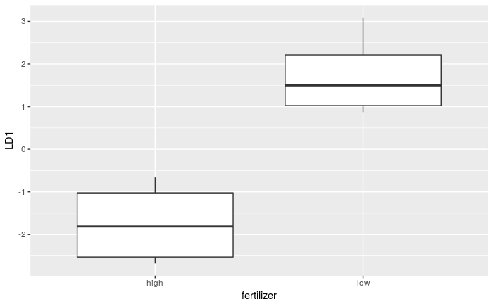

```r
ggplot(d,aes(x=fertilizer,y=LD1))+geom_boxplot()
```

## Potentially misleading

- These are like regression slopes:

```r
hilo.1$scaling
```

```
              LD1
yield  -0.7666761
weight -1.2513563
```

- Reflect change in LD1 score for 1-unit change in variables.
- But one-unit change in variables might not be comparable:

```r
summary(hilo)
```

```
  fertilizer            yield           weight
 Length:8           Min.   :29.00   Min.   :10.00
 Class :character   1st Qu.:32.75   1st Qu.:11.75
 Mode  :character   Median :34.00   Median :13.00
                    Mean   :33.75   Mean   :12.62
                    3rd Qu.:35.00   3rd Qu.:14.00
                    Max.   :38.00   Max.   :14.00
```

- Here, IQRs *identical*, so 1-unit change in each variable means same thing.

## What else is in `hilo.pred?`

```r
names(hilo.pred)
```

```
[1] "class"     "posterior" "x"
```

- `class`: predicted fertilizer level (based on values of `yield` and `weight`).
- `posterior`: predicted probability of being low or high fertilizer given `yield` and `weight`.

## Predictions and predicted groups

… based on `yield` and `weight`:

```r
cbind(hilo,predicted=hilo.pred$class)
```

| fertilizer | yield | weight | predicted |
| --- | --- | --- | --- |
| low | 34 | 10 | low |
| low | 29 | 14 | low |
| low | 35 | 11 | low |
| low | 32 | 13 | low |
| high | 33 | 14 | high |
| high | 38 | 12 | high |
| high | 34 | 13 | high |
| high | 35 | 14 | high |

```r
table(obs=hilo$fertilizer,pred=hilo.pred$class)
```

```
      pred
obs    high low
  high    4   0
  low     0   4
```

Or:

```r
d2=tibble(obs=hilo$fertilizer,pred=hilo.pred$class)
d2 %>% count(obs,pred)
```

| obs | pred | n |
| --- | --- | --- |
| high | high | 4 |
| low | low | 4 |

or even

```r
d2=tibble(obs=hilo$fertilizer,pred=hilo.pred$class)
d2 %>% count(obs,pred) %>%
  mutate(stat=ifelse(obs==pred,"correct","wrong"))
```

| obs | pred | n | stat |
| --- | --- | --- | --- |
| high | high | 4 | correct |
| low | low | 4 | correct |

## Understanding the predicted groups

- Each predicted fertilizer level is exactly same as observed one (perfect prediction).
- Table shows no errors: all values on top-left to bottom-right diagonal.

## Posterior probabilities

show how clear-cut the classification decisions were:

```r
pp=round(hilo.pred$posterior,4)
d=cbind(hilo,hilo.pred$x,pp)
d
```

|  | fertilizer | yield | weight | LD1 | high | low |
| --- | --- | --- | --- | --- | --- | --- |
| 1 | low | 34 | 10 | 3.0931414 | 0.0000 | 1.0000 |
| 2 | low | 29 | 14 | 1.9210963 | 0.0012 | 0.9988 |
| 3 | low | 35 | 11 | 1.0751090 | 0.0232 | 0.9768 |
| 4 | low | 32 | 13 | 0.8724245 | 0.0458 | 0.9542 |
| 5 | high | 33 | 14 | -1.1456079 | 0.9818 | 0.0182 |
| 6 | high | 38 | 12 | -2.4762756 | 0.9998 | 0.0002 |
| 7 | high | 34 | 13 | -0.6609276 | 0.9089 | 0.0911 |
| 8 | high | 35 | 14 | -2.6789600 | 0.9999 | 0.0001 |

Only obs. 7 has any doubt: `yield` low for a high-fertilizer, but high `weight` makes up for it.

## Example 2: the peanuts

```r
my_url="http://www.utsc.utoronto.ca/~butler/d29/peanuts.txt"
peanuts=read_delim(my_url," ")
peanuts
```

| obs | location | variety | y | smk | w |
| --- | --- | --- | --- | --- | --- |
| 1 | 1 | 5 | 195.3 | 153.1 | 51.4 |
| 2 | 1 | 5 | 194.3 | 167.7 | 53.7 |
| 3 | 2 | 5 | 189.7 | 139.5 | 55.5 |
| 4 | 2 | 5 | 180.4 | 121.1 | 44.4 |
| 5 | 1 | 6 | 203.0 | 156.8 | 49.8 |
| 6 | 1 | 6 | 195.9 | 166.0 | 45.8 |
| 7 | 2 | 6 | 202.7 | 166.1 | 60.4 |
| 8 | 2 | 6 | 197.6 | 161.8 | 54.1 |
| 9 | 1 | 8 | 193.5 | 164.5 | 57.8 |
| 10 | 1 | 8 | 187.0 | 165.1 | 58.6 |

[output cut: 2 more lines]

Recall: `location` and `variety` both significant in MANOVA. Make combo of them (over):

## Location-variety combos

```r
peanuts.combo = peanuts %>% unite(combo,variety,location)
peanuts.combo
```

| obs | combo | y | smk | w |
| --- | --- | --- | --- | --- |
| 1 | 5_1 | 195.3 | 153.1 | 51.4 |
| 2 | 5_1 | 194.3 | 167.7 | 53.7 |
| 3 | 5_2 | 189.7 | 139.5 | 55.5 |
| 4 | 5_2 | 180.4 | 121.1 | 44.4 |
| 5 | 6_1 | 203.0 | 156.8 | 49.8 |
| 6 | 6_1 | 195.9 | 166.0 | 45.8 |
| 7 | 6_2 | 202.7 | 166.1 | 60.4 |
| 8 | 6_2 | 197.6 | 161.8 | 54.1 |
| 9 | 8_1 | 193.5 | 164.5 | 57.8 |
| 10 | 8_1 | 187.0 | 165.1 | 58.6 |

[output cut: 2 more lines]

## Discriminant analysis

```r
peanuts.1=lda(combo~y+smk+w,data=peanuts.combo)
peanuts.1
```

```
Call:
lda(combo ~ y + smk + w, data = peanuts.combo)

Prior probabilities of groups:
      5_1       5_2       6_1       6_2       8_1       8_2
0.1666667 0.1666667 0.1666667 0.1666667 0.1666667 0.1666667

Group means:
         y    smk     w
5_1 194.80 160.40 52.55
5_2 185.05 130.30 49.95
6_1 199.45 161.40 47.80
6_2 200.15 163.95 57.25
8_1 190.25 164.80 58.20
8_2 200.75 170.30 66.10

Coefficients of linear discriminants:
           LD1         LD2         LD3
y   -0.4027356 -0.02967881  0.18839237
smk -0.1727459  0.06794271 -0.09386294
w    0.5792456  0.16300221  0.07341123

Proportion of trace:
   LD1    LD2    LD3
0.8424 0.1317 0.0258
```

Or, in pieces:

```r
peanuts.1$scaling
```

and

```r
peanuts.1$svd
```

- Now 3 LDs (3 variables, 6 groups, $\min(3,6-1)=3$).
- First: relationship of LDs to original variables. Look for coeffs far from zero: here,
  - high `LD1` mainly high `w` or low `y`.
- high `LD2` mainly high `w`.
- `svd` values show relative importance of LDs: `LD1` much more important than `LD2`.

## Group means by variable

```r
peanuts.1$means
```

- `5_2` clearly smallest on `y`, `smk`, near smallest on `w`
- `8_2` clearly biggest on `smk`, `w`, also largest on `y`
- `8_1` large on `w`, small on `y`.
- `scaling` links LDs with original variables, `means` links original variables with groups.
- Implies: link between groups and LDs.

## The predictions and misclassification

```r
peanuts.pred=predict(peanuts.1)
table(obs=peanuts.combo$combo,
      pred=peanuts.pred$class)
```

```
     pred
obs   5_1 5_2 6_1 6_2 8_1 8_2
  5_1   2   0   0   0   0   0
  5_2   0   2   0   0   0   0
  6_1   0   0   2   0   0   0
  6_2   1   0   0   1   0   0
  8_1   0   0   0   0   2   0
  8_2   0   0   0   0   0   2
```

Actually classified very well. Only one `6_2` classified as a `5_1`, rest all correct.

Or:

```r
dd=tibble(obs=peanuts.combo$combo,pred=peanuts.pred$class)
dd
```

| obs | pred |
| --- | --- |
| 5_1 | 5_1 |
| 5_1 | 5_1 |
| 5_2 | 5_2 |
| 5_2 | 5_2 |
| 6_1 | 6_1 |
| 6_1 | 6_1 |
| 6_2 | 6_2 |
| 6_2 | 5_1 |
| 8_1 | 8_1 |
| 8_1 | 8_1 |

[output cut: 2 more lines]

```r
dd %>% count(obs,pred)
```

| obs | pred | n |
| --- | --- | --- |
| 5_1 | 5_1 | 2 |
| 5_2 | 5_2 | 2 |
| 6_1 | 6_1 | 2 |
| 6_2 | 5_1 | 1 |
| 6_2 | 6_2 | 1 |
| 8_1 | 8_1 | 2 |
| 8_2 | 8_2 | 2 |

or even

```r
dd %>% count(obs,pred) %>%
  mutate(stat=ifelse(obs==pred,"correct","wrong"))
```

| obs | pred | n | stat |
| --- | --- | --- | --- |
| 5_1 | 5_1 | 2 | correct |
| 5_2 | 5_2 | 2 | correct |
| 6_1 | 6_1 | 2 | correct |
| 6_2 | 5_1 | 1 | wrong |
| 6_2 | 6_2 | 1 | correct |
| 8_1 | 8_1 | 2 | correct |
| 8_2 | 8_2 | 2 | correct |

## Posterior probabilities

```r
pp=round(peanuts.pred$posterior,2)
peanuts.combo %>% select(-c(y,smk,w)) %>%
   cbind(.,pred=peanuts.pred$class,pp)
```

|  | obs | combo | pred | 5_1 | 5_2 | 6_1 | 6_2 | 8_1 | 8_2 |
| --- | --- | --- | --- | --- | --- | --- | --- | --- | --- |
| 1 | 1 | 5_1 | 5_1 | 0.69 | 0 | 0 | 0.31 | 0.00 | 0.00 |
| 2 | 2 | 5_1 | 5_1 | 0.73 | 0 | 0 | 0.27 | 0.00 | 0.00 |
| 3 | 3 | 5_2 | 5_2 | 0.00 | 1 | 0 | 0.00 | 0.00 | 0.00 |
| 4 | 4 | 5_2 | 5_2 | 0.00 | 1 | 0 | 0.00 | 0.00 | 0.00 |
| 5 | 5 | 6_1 | 6_1 | 0.00 | 0 | 1 | 0.00 | 0.00 | 0.00 |
| 6 | 6 | 6_1 | 6_1 | 0.00 | 0 | 1 | 0.00 | 0.00 | 0.00 |
| 7 | 7 | 6_2 | 6_2 | 0.13 | 0 | 0 | 0.87 | 0.00 | 0.00 |
| 8 | 8 | 6_2 | 5_1 | 0.53 | 0 | 0 | 0.47 | 0.00 | 0.00 |
| 9 | 9 | 8_1 | 8_1 | 0.02 | 0 | 0 | 0.02 | 0.75 | 0.21 |
| 10 | 10 | 8_1 | 8_1 | 0.00 | 0 | 0 | 0.00 | 0.99 | 0.01 |

[output cut: 2 more lines]

*Some* doubt about which combo each plant belongs in, but not too much. The one misclassified plant was a close call.

## Discriminant scores, again

- How are discriminant scores related to original variables?
- Construct data frame with original data and discriminant scores side by side:

```r
peanuts.1$scaling
```

```
           LD1         LD2         LD3
y   -0.4027356 -0.02967881  0.18839237
smk -0.1727459  0.06794271 -0.09386294
w    0.5792456  0.16300221  0.07341123
```

```r
lds=round(peanuts.pred$x,2)
mm=with(peanuts.combo,
  data.frame(combo,y,smk,w,lds))
```

- LD1 positive if `w` large and/or `y` small.
- LD2 positive if `w` large.
  - But, what if `y, smk, w` differ in spread?

## Discriminant scores for data

```r
mm
```

- Obs. 5 and 6 have most negative `LD1`: large `y`, small `w`.
- Obs. 4 has most negative `LD2`: small `w`.

Plot:

```r
quartiles = peanuts %>% select(y:w) %>%
  map_df(quantile, c(0.25,0.75))
quartiles
```

| y | smk | w |
| --- | --- | --- |
| 192.550 | 155.875 | 51.00 |
| 200.375 | 166.275 | 59.05 |

```r
new=with(quartiles,crossing(y,smk,w))
```

## Predict typical LD1 scores

First and third quartiles for three response variables (reading down):

```r
quartiles = peanuts %>% select(y:w) %>%
  map_df(quantile, c(0.25,0.75))
quartiles
new=with(quartiles,crossing(y,smk,w))
```

## The combinations

```r
new
pp=predict(peanuts.1,new)
```

## Predicted typical LD1 scores

```r
cbind(new,pp$x) %>% arrange(LD1)
```

- Very negative LD1 score with large `y` and small `w`
- `smk` doesn’t contribute much to LD1
- Very positive LD1 score with small `y` and large `w`.
- Same as we saw from Coefficients of Linear Discriminants.

## Plot LD1 vs. LD2, labelling by combo

```r
g=ggplot(mm,aes(x=LD1,y=LD2,colour=combo,
  label=combo))+geom_point()+
  geom_text_repel()+guides(colour=F) ; g
```

## “Bi-plot” from `ggbiplot`

See installation notes below.

```r
ggbiplot::ggbiplot(peanuts.1,
  groups=factor(peanuts.combo$combo))
```

## Installing `ggbiplot`

- `ggbiplot` not on CRAN, so usual `install.packages` will not work.
- Install package `devtools` first (once):

```r
install.packages("devtools")
```

- Then install `ggbiplot` (once):

```r
library(devtools)
install_github("vqv/ggbiplot")
```

I already have these installed, so I don’t need to install them again. For you, take the `eval=FALSE` out of the code chunk header (once) to install them (and then put it back).

## Cross-validation

- So far, have predicted group membership from same data used to form the groups — dishonest!
- Better: *cross-validation*: form groups from all observations *except one*, then predict group membership for that left-out observation.
- No longer cheating!
- Illustrate with peanuts data again.

## Misclassifications

- Fitting and prediction all in one go:

```r
peanuts.cv=lda(combo~y+smk+w,
  data=peanuts.combo,CV=T)
table(obs=peanuts.combo$combo,
      pred=peanuts.cv$class)
```

- Some more misclassification this time.

## Repeat of LD plot

```r
g
```

## Posterior probabilities

```r
pp=round(peanuts.cv$posterior,3)
data.frame(obs=peanuts.combo$combo,
           pred=peanuts.cv$class,pp)
```

## Why more misclassification?

- When predicting group membership for one observation, only uses the *other one* in that group.
- So if two in a pair are far apart, or if two groups overlap, great potential for misclassification.
- Groups `5_1` and `6_2` overlap.
- `5_2` closest to `8_1`s looks more like an `8_1` than a `5_2` (other one far away).
- `8_1`s relatively far apart and close to other things, so one appears to be a `5_2` and the other an `8_2`.

## Example 3: professions and leisure activities

- 15 individuals from three different professions (politicians, administrators and belly dancers) each participate in four different leisure activities: reading, dancing, TV watching and skiing. After each activity they rate it on a 0–10 scale.
- Some of the data:

```
bellydancer 7 10 6 5
bellydancer 8 9 5 7
bellydancer 5 10 5 8
politician 5 5 5 6
politician 4 5 6 5
admin 4 2 2 5
admin 7 1 2 4
admin 6 3 3 3
```

- How can we best use the scores on the activities to predict a person’s profession?
- Or, what combination(s) of scores best separate data into profession groups?

## Discriminant analysis

```r
my_url="http://www.utsc.utoronto.ca/~butler/d29/profile.txt"
active=read_delim(my_url," ")
active.1=lda(job~reading+dance+tv+ski,data=active)
active.1$svd
active.1$scaling
```

- Two discriminants, first fair bit more important than second.
- `LD1` depends (negatively) most on `dance`, a bit on `tv`.
- `LD2` depends mostly on `tv`.

## Misclassification

```r
active.pred=predict(active.1)
table(obs=active$job,pred=active.pred$class)
```

Everyone correctly classified. Or:

```r
tibble(obs=active$job,pred=active.pred$class) %>%
  count(obs,pred) %>%
  mutate(stat=ifelse(obs==pred,"correct","wrong"))
```

## Plotting LDs

```r
mm=data.frame(job=active$job,active.pred$x,person=1:15)
g=ggplot(mm,aes(x=LD1,y=LD2,
    colour=job,label=job))+geom_point()+
    geom_text_repel()+guides(colour=F) ; g
```

## Biplot

```r
ggbiplot::ggbiplot(active.1,groups=active$job)
```

## Comments on plot

- Groups well separated: bellydancers top left, administrators top right, politicians lower middle.
- Bellydancers most negative on `LD1`: like dancing most.
- Administrators most positive on `LD1`: like dancing least.
- Politicians most negative on `LD2`: like TV-watching most.

## Plotting individual `persons`

Make `label` be identifier of person. Now need legend:

```r
ggplot(mm,aes(x=LD1,y=LD2,
    colour=job,label=person))+geom_point()+
    geom_text_repel()
```

## Posterior probabilities

```r
pp=round(active.pred$posterior,3)
data.frame(obs=active$job,pred=active.pred$class,pp)
```

Not much doubt.

## Cross-validating the jobs-activities data

Recall: no need for `predict`. Just pull out `class` and make a table:

```r
active.cv=lda(job~reading+dance+tv+ski,
  data=active,CV=T)
table(obs=active$job,pred=active.cv$class)
```

Or:

```r
tibble(obs=active$job,pred=active.cv$class) %>%
  count(obs,pred) %>%
  mutate(is_correct=ifelse(obs==pred,"yes","no"))
```

This time one of the bellydancers was classified as a politician.

## and look at the posterior probabilities

picking out the ones where things are not (absolutely) certain:

```r
pp=round(active.cv$posterior,3)
data.frame(obs=active$job,pred=active.cv$class,pp) %>%
  mutate(max=pmax(admin,bellydancer,politician)) %>%
  filter(max<0.9995)
```

- Bellydancer was “definitely” a politician!
- One of the administrators might have been a politician too.

## Why did things get misclassified?

```r
g
```

```
- Go back to plot of discriminant scores:
- one bellydancer much closer to the politicians,
- one administrator a bit closer to the politicians.
```

## Reading in

```r
my_url="http://www.utsc.utoronto.ca/~butler/d29/remote-sensing.txt"
crops=read_table(my_url)
crops
```

## Starting off: number of LDs

```r
crops.lda=lda(crop~x1+x2+x3+x4,data=crops)
crops.lda
```

```r
crops.lda$svd
```

## Connecting original variables and LDs

```r
crops.lda$means
round(crops.lda$scaling,3)
```

- Links groups to original variables to LDs.

```r
round(crops.lda$scaling,3)
```

- `LD1` mostly `x1` (minus), so clover low on `LD1`, corn high.
- `LD2` `x3` (minus), `x2` (plus), so sugarbeets should be high on `LD2`.

## Predictions

- Thus:

```r
crops.pred=predict(crops.lda)
table(obs=crops$crop,pred=crops.pred$class)
```

- Not very good, eg. only 6 of 11 `Clover` classified correctly.
- Set up for plot:

```r
mm=data.frame(crop=crops$crop,crops.pred$x)
mm
```

|  | crop | LD1 | LD2 | LD3 | LD4 |
| --- | --- | --- | --- | --- | --- |
| 1 | Corn | 1.05991249 | -0.38894000 | 0.22804664 | 0.17329536 |
| 2 | Corn | 1.20676907 | -0.44828745 | -0.10850799 | 0.03682165 |
| 3 | Corn | 0.99386741 | 0.02636835 | -0.22752734 | 0.31756405 |
| 4 | Corn | 1.01635084 | -0.05437814 | -0.81235112 | -0.03641650 |
| 5 | Corn | 1.42721029 | -0.89830567 | -0.35167913 | -0.44441199 |
| 6 | Corn | 1.00943331 | -0.01291854 | -0.45951757 | 0.93404333 |
| 7 | Corn | 1.36742112 | -0.30449239 | 1.64878237 | -1.58887579 |
| 8 | Soybeans | 0.78419509 | 0.22367799 | -0.66493667 | 0.02943594 |
| 9 | Soybeans | 0.54601362 | 0.04701353 | -0.32195527 | -0.13659036 |
| 10 | Soybeans | 0.67169078 | 0.33248879 | -0.65599552 | 0.15015731 |

[output cut: 26 more lines]

## Plotting the LDs

```r
ggplot(mm,aes(x=LD1,y=LD2,colour=crop,shape=crop))+
  geom_point()
```

## Biplot

```r
ggbiplot::ggbiplot(crops.lda,groups=crops$crop)
```

- Corn high on LD1 (right).
- Clover all over the place, but mostly low on LD1 (left).
- Sugarbeets tend to be high on LD2.
- Cotton tends to be low on LD2.
- Very mixed up.

## Try removing Clover

```r
crops %>% filter(crop!="Clover") -> crops2
crops2.lda=lda(crop~x1+x2+x3+x4,data=crops2)
```

- LDs for `crops2` will be different from before.
- Concentrate on plot and posterior probs.

```r
crops2.pred=predict(crops2.lda)
mm=data.frame(crop=crops2$crop,crops2.pred$x)
```

## `lda output`

Different from before:

```r
crops2.lda
```

## Plot

A bit more clustered:

```r
ggplot(mm,aes(x=LD1,y=LD2,colour=crop,shape=crop))+
  geom_point()
```

## Biplot

```r
ggbiplot::ggbiplot(crops2.lda,groups=crops2$crop)
```

## Quality of classification

```r
table(obs=crops2$crop,pred=crops2.pred$class)
```

or:

```r
tibble(obs=crops2$crop,pred=crops2.pred$class) %>%
  dplyr::count(obs,pred) %>%
  mutate(is_correct=ifelse(obs==pred,"yes","no"))
```

| obs | pred | n | is_correct |
| --- | --- | --- | --- |
| Corn | Corn | 6 | yes |
| Corn | Soybeans | 1 | no |
| Cotton | Cotton | 4 | yes |
| Cotton | Soybeans | 2 | no |
| Soybeans | Corn | 2 | no |
| Soybeans | Soybeans | 3 | yes |
| Soybeans | Sugarbeets | 1 | no |
| Sugarbeets | Soybeans | 3 | no |
| Sugarbeets | Sugarbeets | 3 | yes |

Better.

## Posterior probs, the wrong ones

```r
post=round(crops2.pred$posterior,3)
data.frame(obs=crops2$crop,pred=crops2.pred$class,post) %>%
  filter(obs!=pred)
```

- These were the misclassified ones, but the posterior probability of being correct was not usually too low.
- The correctly-classified ones are sometimes more clear-cut, but not completely convincing:

```r
data.frame(obs=crops2$crop,pred=crops2.pred$class,post) %>%
  filter(obs==pred)
```

## MANOVA

Began discriminant analysis as a followup to MANOVA. Do our variables significantly separate the crops (excluding Clover)?

```r
response=with(crops2,cbind(x1,x2,x3,x4))
crops2.manova=manova(response~crop,data=crops2)
summary(crops2.manova)
```

Yes, at least one of the crops differs (in means) from the others. So it is worth doing this analysis.

Having said that, the P-value is not *very* small, so the separation of crops might not be very strong (as we saw).

We did this the wrong way around, though!

## The right way around

- *First*, do a MANOVA to see whether any of the groups differ significantly on any of the variables.
- *If the MANOVA is significant*, do a discriminant analysis in the hopes of understanding how the groups are different.
- For remote-sensing data (without Clover):
  - LD1 a fair bit more important than LD2 (definitely ignore LD3).
  - LD1 depends mostly on `x1`, on which Cotton was high and Corn was low.
- Discriminant analysis in MANOVA plays the same kind of role that Tukey does in ANOVA.